# 03_b — Transfer v1 Audit & Visualisation

**Purpose:** Post-hoc audit of the three transfer-learning variants (V1-A raw-edges, V1-B frozen-encoder probe, V1-C unsupervised recon-adapt + probe) run by `scripts/run_transfer_v1_three_variants.py`.

**What the scores mean:** Each variant trains a logistic classifier on **ADNI AD vs CN** and then *applies* that classifier to the COVID cohort. The resulting `y_score` is an **"AD-likeness" probability** — *not* a disease-severity or diagnostic score.

**Sections:**

1. Setup & helpers
2. Manifest audit
3. Subject alignment audit (metadata ↔ NPZ)
4. ADNI classification performance (per-fold)
5. COVID score distributions by Grupo and Sex
6. V1-C recon error analysis
7. ROC: Grupo discrimination using AD-likeness scores
8. Optional: MOCA correlations

```python
# ── §1  Setup & helpers ──────────────────────────────────────────────
from __future__ import annotations
import json, sys, warnings
from pathlib import Path

import matplotlib.pyplot as plt
import numpy as np
import pandas as pd
import seaborn as sns
from scipy import stats

warnings.filterwarnings("ignore")
sns.set_theme(style="whitegrid", font_scale=1.1)

# ── Paths (relative to repo root) ──────────────────────────────────────
PROJECT_ROOT = Path("/home/diego/proyectos/vae_AD")
RESULTS_DIR  = PROJECT_ROOT / "results" / "vae_3channels_beta65_pro"
TRANSFER_OUT = RESULTS_DIR / "transfer_v1_paper_output"
META_CSV     = PROJECT_ROOT / "data" / "SubjectsData_AAL3_COVID.csv"
COVID_NPZ    = (
    PROJECT_ROOT / "data"
    / "COVID_AAL3_Tensor_v1_AAL3_131ROIs_OMST_GCE_Signed_GrangerLag1_ChNorm_ROIreorderedYeo17_ParallelTuned"
    / "GLOBAL_TENSOR_from_COVID_AAL3_Tensor_v1_AAL3_131ROIs_OMST_GCE_Signed_GrangerLag1_ChNorm_ROIreorderedYeo17_ParallelTuned.npz"
)

# output dirs
FIG_DIR = TRANSFER_OUT / "Figures"
FIG_DIR.mkdir(parents=True, exist_ok=True)

# ── src/ on path ───────────────────────────────────────────────────────
sys.path.insert(0, str(PROJECT_ROOT / "src"))
from betavae_xai.utils.id_utils import normalize_id, normalize_id_array, normalize_id_series

# ── Helper: save figure ────────────────────────────────────────────────
def savefig(fig, name: str, dpi: int = 200) -> Path:
    """Save to FIG_DIR/<name>.png and return the path."""
    p = FIG_DIR / f"{name}.png"
    fig.savefig(p, dpi=dpi, bbox_inches="tight")
    print(f"  -> saved {p.relative_to(PROJECT_ROOT)}")
    return p

print("Setup OK")
```

```
Setup OK
```

## 2 — Manifest Audit

Load `run_manifest.json` and verify key fields are present and non-null.

```python
# ── §2  Manifest audit ──────────────────────────────────────────────
manifest = json.loads((TRANSFER_OUT / "run_manifest.json").read_text())

REQUIRED_KEYS = [
    "created_utc", "git_hash", "fold_ids", "selected_channel_names",
    "compatibility", "youden_threshold", "latent_dim", "seeds",
    "v1a_settings", "v1b_settings", "v1c_settings", "outputs_written",
]

print("=== Manifest Audit ===")
for k in REQUIRED_KEYS:
    v = manifest.get(k)
    status = "OK" if v is not None else "MISSING"
    val_str = str(v)[:80] if v is not None else ""
    print(f"  [{status}] {k}: {val_str}")

print(f"\n  created_utc          : {manifest['created_utc']}")
print(f"  git_hash             : {manifest['git_hash']}")
print(f"  fold_ids             : {manifest['fold_ids']}")
print(f"  selected_channels    : {manifest['selected_channel_names']}")
print(f"  ROI hash             : {manifest['compatibility']['roi_hash']}")
print(f"  Channel hash         : {manifest['compatibility']['ch_hash']}")
print(f"  youden_threshold     : {manifest['youden_threshold']:.6f}")
print(f"  latent_dim           : {manifest['latent_dim']}")
print(f"  smoke_test           : {manifest.get('smoke_test', 'N/A')}")
print(f"  outputs written      : {len(manifest['outputs_written'])} files")
```

```
=== Manifest Audit ===
  [OK] created_utc: 2026-03-05T21:46:34.317666+00:00
  [OK] git_hash: d81d38d
  [OK] fold_ids: [1, 2, 3, 4, 5]
  [OK] selected_channel_names: ['Pearson_Full_FisherZ_Signed', 'Pearson_OMST_GCE_Signed_Weighted', 'MI_KNN_Symm
  [OK] compatibility: {'roi_hash': 'd116e1fa0baf7864', 'ch_hash': '44cabbb2b87fd825'}
  [OK] youden_threshold: 0.4934522110048675
  [OK] latent_dim: 256
  [OK] seeds: {'SEED_GLOBAL': 42, 'SEED_SAMPLING': 42}
  [OK] v1a_settings: {'features': 'upper_triangle_vectorize (channel-major, edge-major)', 'scaler': '
  [OK] v1b_settings: {'encoder': 'frozen ADNI-trained VAE → μ', 'scaler': 'StandardScaler (fit on ADN
  [OK] v1c_settings: {'lr': 0.0001, 'weight_decay': 1e-06, 'beta_adapt': 1.0, 'max_epochs': 200, 'pat
  [OK] outputs_written: ['Tables/v1A_rawedges_adni_metrics_by_fold.csv', 'Tables/v1A_rawedges_covid_scor

  created_utc          : 2026-03-05T21:46:34.317666+00:00
  git_hash             : d81d38d
  fold_ids             : [1, 2, 3, 4, 5]
  selected_channels    : ['Pearson_Full_FisherZ_Signed', 'Pearson_OMST_GCE_Signed_Weighted', 'MI_KNN_Symmetric']
  ROI hash             : d116e1fa0baf7864
  Channel hash         : 44cabbb2b87fd825
  youden_threshold     : 0.493452
  latent_dim           : 256
  smoke_test           : False
  outputs written      : 23 files
```

## 3 — Subject Alignment Audit

The COVID NPZ stores IDs in field `subject_ids` using the **`ID`** column format (e.g. `CP0008`), while `SubjectsData_AAL3_COVID.csv` uses `SubjectID` (e.g. `333_S_0008`) as primary key, but also has an `ID` column that matches.

We normalise both sides (strip, upper, remove whitespace) and merge on the **`ID`** column.

```python
# ── §3  Subject alignment ──────────────────────────────────────────
meta = pd.read_csv(META_CSV)
npz_data = np.load(str(COVID_NPZ), allow_pickle=True)
npz_ids_raw = npz_data["subject_ids"]

# Normalise IDs
npz_ids_norm = normalize_id_array(npz_ids_raw)
meta["ID_norm"] = normalize_id_series(meta["ID"])

npz_set = set(npz_ids_norm)
meta_set = set(meta["ID_norm"])
intersection = npz_set & meta_set

print("=== Subject Alignment ===")
print(f"  N_meta (CSV)         : {len(meta)}")
print(f"  N_tensor (NPZ)       : {len(npz_ids_norm)}")
print(f"  N_intersection       : {len(intersection)}")
print(f"  dropped_from_meta    : {len(meta_set - npz_set)}  (in CSV but no tensor)")
print(f"  dropped_from_tensor  : {len(npz_set - meta_set)}  (in tensor but no metadata)")

# Show the dropped-from-meta subjects
dropped_meta = meta[~meta["ID_norm"].isin(npz_set)][["SubjectID", "ID", "Grupo", "Sex", "Age"]]
print(f"\nSubjects in metadata but NOT in tensor ({len(dropped_meta)}):")
display(dropped_meta.head(10))

# Sanity: verify ALL NPZ IDs map to metadata
assert len(npz_set - meta_set) == 0, f"Tensor has IDs not in metadata: {npz_set - meta_set}"
print("\nAll 194 tensor subjects have metadata. Alignment OK.")
```

```
=== Subject Alignment ===
  N_meta (CSV)         : 214
  N_tensor (NPZ)       : 194
  N_intersection       : 194
  dropped_from_meta    : 20  (in CSV but no tensor)
  dropped_from_tensor  : 0  (in tensor but no metadata)

Subjects in metadata but NOT in tensor (20):
```

|  | SubjectID | ID | Grupo | Sex | Age |
| --- | --- | --- | --- | --- | --- |
| 3 | 333_S_0004 | CP0004 | CONTROL | M | 59 |
| 4 | 333_S_0005 | CP0005 | CONTROL | F | 54 |
| 10 | 333_S_0012 | CP0012 | COVID | F | 50 |
| 13 | 333_S_0017 | CP0017 | COVID | F | 41 |
| 16 | 333_S_0021 | CP0021 | COVID | F | 42 |
| 21 | 333_S_0026 | CP0026 | COVID | F | 49 |
| 39 | 333_S_0045 | CP0045 | COVID | M | 65 |
| 42 | 333_S_0049 | CP0049 | COVID | F | 50 |
| 68 | 333_S_0080 | CP0080 | CONTROL | F | 33 |
| 90 | 333_S_0109 | CP0109 | COVID | F | 45 |

```
All 194 tensor subjects have metadata. Alignment OK.
```

## 4 — ADNI Classification Performance (per-fold)

Summary of how each variant's LogReg performed on the **ADNI outer-test folds** (AD vs CN). This is the "internal validation" of the transferred classifier.

|  | variant | adni_mean_auc | adni_std_auc | adni_mean_balacc | covid_mean_score_mean | covid_mean_score_std | pct_covid_above_youden | youden_threshold |
| --- | --- | --- | --- | --- | --- | --- | --- | --- |
| 0 | V1-A | 0.807027 | 0.056259 | 0.705968 | 0.167376 | 0.091489 | 0.134021 | 0.493452 |
| 1 | V1-B | 0.775769 | 0.049246 | 0.692415 | 0.229169 | 0.157304 | 0.149485 | 0.493452 |
| 2 | V1-C | 0.761316 | 0.061625 | 0.694238 | 0.314033 | 0.148544 | 0.273196 | 0.493452 |

```
  -> saved results/vae_3channels_beta65_pro/transfer_v1_paper_output/Figures/adni_performance_by_fold.png
```

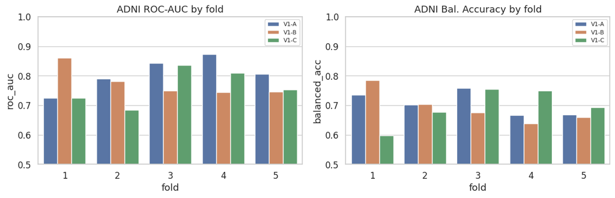

```python
# ── §4  ADNI performance ────────────────────────────────────────────
T = TRANSFER_OUT / "Tables"

adni_a = pd.read_csv(T / "v1A_rawedges_adni_metrics_by_fold.csv").assign(variant="V1-A")
adni_b = pd.read_csv(T / "v1B_probe_adni_metrics_by_fold.csv").assign(variant="V1-B")
adni_c = pd.read_csv(T / "v1C_adapt_probe_adni_metrics_by_fold.csv").assign(variant="V1-C")
adni_all = pd.concat([adni_a, adni_b, adni_c], ignore_index=True)

# Summary table
summary = pd.read_csv(T / "v1_summary_three_variants.csv")
display(summary)

# Per-fold bar plot
fig, axes = plt.subplots(1, 2, figsize=(12, 4))
for ax, metric, label in zip(axes, ["roc_auc", "balanced_acc"], ["ROC-AUC", "Bal. Accuracy"]):
    sns.barplot(data=adni_all, x="fold", y=metric, hue="variant", ax=ax)
    ax.set_title(f"ADNI {label} by fold")
    ax.set_ylim(0.5, 1.0)
    ax.legend(fontsize=8)
fig.tight_layout()
savefig(fig, "adni_performance_by_fold")
plt.show()
```

## 5 — COVID Score Distributions by Grupo & Sex

Merge the ensemble scores from each variant with metadata. The `y_score_mean` represents the **mean across folds** of the AD-likeness probability assigned to each COVID subject.

We compare distributions of COVID vs CONTROL and by Sex.

```python
# ── §5  Load & merge COVID scores with metadata ────────────────────
v1a_scores = pd.read_csv(T / "v1A_rawedges_covid_scores_ensemble.csv").rename(
    columns=lambda c: f"v1a_{c}" if c != "SubjectID" else c
)
v1b_scores = pd.read_csv(T / "v1B_probe_covid_scores_ensemble.csv").rename(
    columns=lambda c: f"v1b_{c}" if c != "SubjectID" else c
)
v1c_scores = pd.read_csv(T / "v1C_adapt_probe_covid_scores_ensemble.csv").rename(
    columns=lambda c: f"v1c_{c}" if c != "SubjectID" else c
)
v1c_recon = pd.read_csv(T / "v1C_adapt_probe_covid_recon_error_ensemble.csv")

# Merge all scores
scores = (
    v1a_scores
    .merge(v1b_scores, on="SubjectID")
    .merge(v1c_scores, on="SubjectID")
    .merge(v1c_recon, on="SubjectID")
)

# Merge with metadata on normalised ID
scores["ID_norm"] = normalize_id_series(scores["SubjectID"])
meta_slim = meta[["ID", "ID_norm", "SubjectID", "Grupo", "Sex", "Age", "MOCA", "CategoríaCOVID"]].copy()
meta_slim = meta_slim.rename(columns={"SubjectID": "SubjectID_long", "ID": "ID_raw"})

df = scores.merge(meta_slim, on="ID_norm", how="inner")
print(f"Merged: {len(df)} subjects  (COVID={sum(df.Grupo=='COVID')}, CONTROL={sum(df.Grupo=='CONTROL')})")

# Summary stats by Grupo
for var, col in [("V1-A", "v1a_y_score_mean"), ("V1-B", "v1b_y_score_mean"), ("V1-C", "v1c_y_score_mean")]:
    g = df.groupby("Grupo")[col].agg(["mean", "std", "median", "min", "max"])
    print(f"\n{var} — y_score_mean by Grupo:")
    display(g.round(4))
```

```
Merged: 194 subjects  (COVID=151, CONTROL=43)

V1-A — y_score_mean by Grupo:
```

| Grupo | mean | std | median | min | max |
| --- | --- | --- | --- | --- | --- |
| CONTROL | 0.1482 | 0.2435 | 0.0184 | 0.0 | 0.9099 |
| COVID | 0.1728 | 0.2696 | 0.0181 | 0.0 | 0.9958 |

```
V1-B — y_score_mean by Grupo:
```

| Grupo | mean | std | median | min | max |
| --- | --- | --- | --- | --- | --- |
| CONTROL | 0.2199 | 0.2372 | 0.0896 | 0.0012 | 0.9443 |
| COVID | 0.2318 | 0.2359 | 0.1471 | 0.0020 | 0.9589 |

```
V1-C — y_score_mean by Grupo:
```

| Grupo | mean | std | median | min | max |
| --- | --- | --- | --- | --- | --- |
| CONTROL | 0.2941 | 0.2666 | 0.2060 | 0.0091 | 0.9227 |
| COVID | 0.3197 | 0.2788 | 0.2589 | 0.0054 | 0.9369 |

```
  -> saved results/vae_3channels_beta65_pro/transfer_v1_paper_output/Figures/covid_scores_by_grupo_violin.png
```

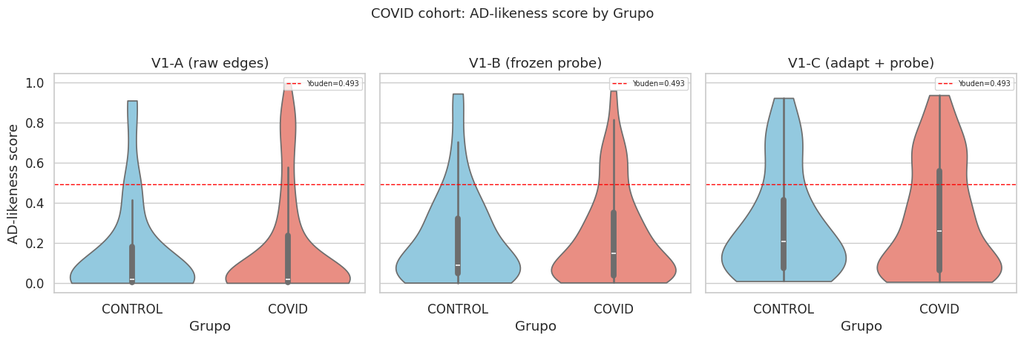

```
  -> saved results/vae_3channels_beta65_pro/transfer_v1_paper_output/Figures/covid_scores_by_sex_grupo.png
```

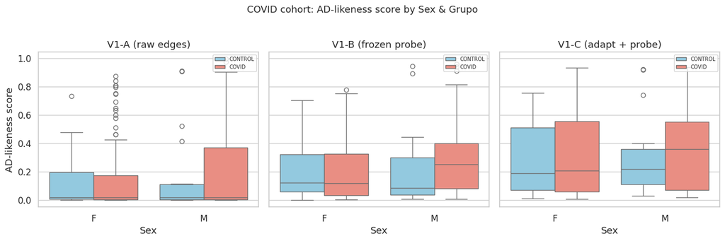

```python
# ── §5b  Violin plots: score distributions by Grupo ─────────────────
score_cols = {
    "V1-A (raw edges)": "v1a_y_score_mean",
    "V1-B (frozen probe)": "v1b_y_score_mean",
    "V1-C (adapt + probe)": "v1c_y_score_mean",
}

fig, axes = plt.subplots(1, 3, figsize=(14, 4.5), sharey=True)
for ax, (label, col) in zip(axes, score_cols.items()):
    sns.violinplot(data=df, x="Grupo", y=col, ax=ax, inner="box",
                   palette={"COVID": "salmon", "CONTROL": "skyblue"}, cut=0)
    youden = manifest["youden_threshold"]
    ax.axhline(youden, color="red", ls="--", lw=1, label=f"Youden={youden:.3f}")
    ax.set_title(label)
    ax.set_ylabel("AD-likeness score" if ax == axes[0] else "")
    ax.legend(fontsize=7, loc="upper right")
fig.suptitle("COVID cohort: AD-likeness score by Grupo", fontsize=13, y=1.02)
fig.tight_layout()
savefig(fig, "covid_scores_by_grupo_violin")
plt.show()

# By Sex
fig, axes = plt.subplots(1, 3, figsize=(14, 4.5), sharey=True)
for ax, (label, col) in zip(axes, score_cols.items()):
    sns.boxplot(data=df, x="Sex", y=col, hue="Grupo", ax=ax,
                palette={"COVID": "salmon", "CONTROL": "skyblue"})
    ax.set_title(label)
    ax.set_ylabel("AD-likeness score" if ax == axes[0] else "")
    ax.legend(fontsize=7, loc="upper right")
fig.suptitle("COVID cohort: AD-likeness score by Sex & Grupo", fontsize=13, y=1.02)
fig.tight_layout()
savefig(fig, "covid_scores_by_sex_grupo")
plt.show()
```

## 6 — V1-C Reconstruction Error Analysis

V1-C adapts the VAE (unsupervised) on COVID data before extracting latents. The **reconstruction error** measures how well the adapted VAE reconstructs each subject.

We check:

- Whether recon error differs between COVID and CONTROL
- Whether recon error correlates with the AD-likeness score (if it does, the score might partly reflect OOD-ness rather than disease signal)

```
  -> saved results/vae_3channels_beta65_pro/transfer_v1_paper_output/Figures/v1c_recon_error_analysis.png
```

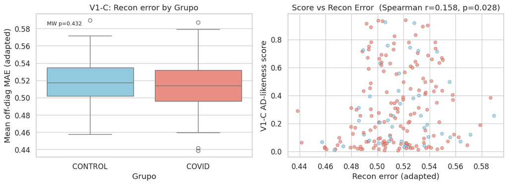

```
Recon error by Grupo:
```

| Grupo | count | mean | std | min | 25% | 50% | 75% | max |
| --- | --- | --- | --- | --- | --- | --- | --- | --- |
| CONTROL | 43.0 | 0.5186 | 0.0274 | 0.4574 | 0.5019 | 0.5174 | 0.5347 | 0.5896 |
| COVID | 151.0 | 0.5144 | 0.0258 | 0.4387 | 0.4962 | 0.5137 | 0.5318 | 0.5870 |

```python
# ── §6  Recon error analysis ─────────────────────────────────────────
fig, axes = plt.subplots(1, 2, figsize=(12, 4.5))

# 6a: Recon error by Grupo
ax = axes[0]
sns.boxplot(data=df, x="Grupo", y="recon_error_mean", ax=ax,
            palette={"COVID": "salmon", "CONTROL": "skyblue"})
ax.set_title("V1-C: Recon error by Grupo")
ax.set_ylabel("Mean off-diag MAE (adapted)")

# Mann-Whitney test
covid_re = df.loc[df.Grupo == "COVID", "recon_error_mean"]
ctrl_re  = df.loc[df.Grupo == "CONTROL", "recon_error_mean"]
mw_stat, mw_p = stats.mannwhitneyu(covid_re, ctrl_re, alternative="two-sided")
ax.text(0.05, 0.95, f"MW p={mw_p:.3g}", transform=ax.transAxes, va="top", fontsize=9)

# 6b: Scatter: V1-C score vs recon error
ax = axes[1]
ax.scatter(df["recon_error_mean"], df["v1c_y_score_mean"],
           c=df["Grupo"].map({"COVID": "salmon", "CONTROL": "skyblue"}),
           edgecolors="k", lw=0.3, s=30, alpha=0.7)
r_sp, p_sp = stats.spearmanr(df["recon_error_mean"], df["v1c_y_score_mean"])
ax.set_xlabel("Recon error (adapted)")
ax.set_ylabel("V1-C AD-likeness score")
ax.set_title(f"Score vs Recon Error  (Spearman r={r_sp:.3f}, p={p_sp:.2g})")

fig.tight_layout()
savefig(fig, "v1c_recon_error_analysis")
plt.show()

print(f"\nRecon error by Grupo:")
display(df.groupby("Grupo")["recon_error_mean"].describe().round(4))
```

## 7 — ROC: Grupo Discrimination Using AD-Likeness Scores

As a **descriptive analysis**, we ask: *can the AD-likeness score (trained purely on ADNI) separate COVID from CONTROL?* This is purely observational — not a diagnostic claim.

We compute a ROC curve treating Grupo as the binary label (COVID=1, CONTROL=0) and each variant's `y_score_mean` as the predictor.

```
  -> saved results/vae_3channels_beta65_pro/transfer_v1_paper_output/Figures/roc_grupo_discrimination.png
```

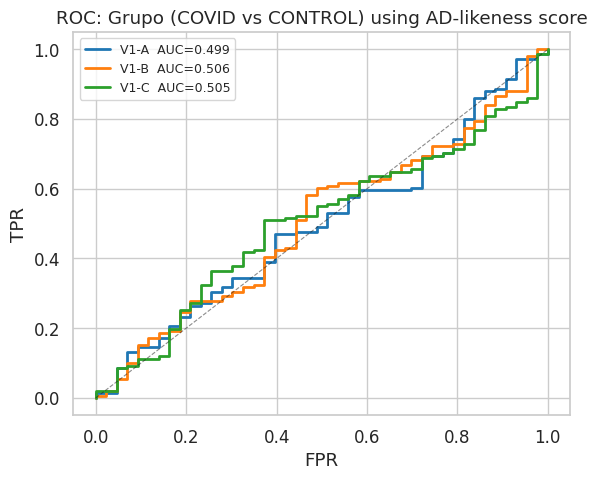

```
Grupo discrimination AUCs (descriptive, not cross-validated):
  V1-A (raw edges): 0.4987
  V1-B (frozen probe): 0.5059
  V1-C (adapt + probe): 0.5049
```

```python
# ── §7  ROC for Grupo ────────────────────────────────────────────────
from sklearn.metrics import roc_auc_score, roc_curve

y_grupo = (df["Grupo"] == "COVID").astype(int).values

fig, ax = plt.subplots(figsize=(6, 5))
for label, col, color in [
    ("V1-A", "v1a_y_score_mean", "tab:blue"),
    ("V1-B", "v1b_y_score_mean", "tab:orange"),
    ("V1-C", "v1c_y_score_mean", "tab:green"),
]:
    auc_val = roc_auc_score(y_grupo, df[col])
    fpr, tpr, _ = roc_curve(y_grupo, df[col])
    ax.plot(fpr, tpr, label=f"{label}  AUC={auc_val:.3f}", color=color, lw=2)

ax.plot([0, 1], [0, 1], "k--", lw=0.8, alpha=0.5)
ax.set_xlabel("FPR")
ax.set_ylabel("TPR")
ax.set_title("ROC: Grupo (COVID vs CONTROL) using AD-likeness score")
ax.legend(fontsize=9)
fig.tight_layout()
savefig(fig, "roc_grupo_discrimination")
plt.show()

print("\nGrupo discrimination AUCs (descriptive, not cross-validated):")
for label, col in score_cols.items():
    print(f"  {label}: {roc_auc_score(y_grupo, df[col]):.4f}")
```

## 8 — Optional: MOCA Correlations

MOCA (Montreal Cognitive Assessment) is available in the metadata. We check whether AD-likeness scores correlate with MOCA. Note: MOCA=30 is perfect; lower scores indicate cognitive impairment.

```
Subjects with MOCA: 194 / 194
  -> saved results/vae_3channels_beta65_pro/transfer_v1_paper_output/Figures/moca_vs_scores.png
```

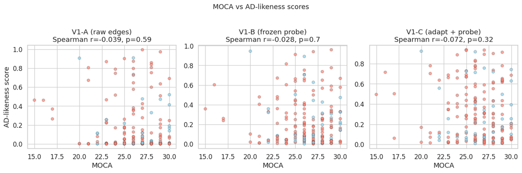

```python
# ── §8  MOCA correlations ────────────────────────────────────────────
df_moca = df.dropna(subset=["MOCA"]).copy()
print(f"Subjects with MOCA: {len(df_moca)} / {len(df)}")

if len(df_moca) > 10:
    fig, axes = plt.subplots(1, 3, figsize=(14, 4.5))
    for ax, (label, col) in zip(axes, score_cols.items()):
        ax.scatter(df_moca["MOCA"], df_moca[col],
                   c=df_moca["Grupo"].map({"COVID": "salmon", "CONTROL": "skyblue"}),
                   edgecolors="k", lw=0.3, s=30, alpha=0.7)
        r_sp, p_sp = stats.spearmanr(df_moca["MOCA"], df_moca[col])
        ax.set_xlabel("MOCA")
        ax.set_ylabel("AD-likeness score" if ax == axes[0] else "")
        ax.set_title(f"{label}\nSpearman r={r_sp:.3f}, p={p_sp:.2g}")
    fig.suptitle("MOCA vs AD-likeness scores", fontsize=13, y=1.02)
    fig.tight_layout()
    savefig(fig, "moca_vs_scores")
    plt.show()
else:
    print("Too few subjects with MOCA for meaningful analysis.")
```

## 8b — COVID vs CONTROL Classification: Per-ADNI-Fold Latent Features

### The Latent Misalignment Problem (Early Fusion ≡ Invalid)

The original v1 pipeline extracted latent $\mu$ from each of the 5 ADNI-fold VAEs and **averaged them element-wise** before feeding them to the classifier. This is **mathematically invalid**.

**Reason:** VAEs trained independently on different folds are *not identifiable*. Their latent dimensions are not permutation-aligned — dimension $j$ in $\text{VAE}_{\text{fold}=1}$ may encode a completely different connectivity pattern than dimension $j$ in $\text{VAE}_{\text{fold}=2}$. Averaging $\mu_{\text{fold}=1}$ with $\mu_{\text{fold}=2}$ therefore **destroys the topological structure** of each individual representation.

### Solution: Late Fusion

We run the full nested-CV classification pipeline **independently** on each ADNI-fold's latent representation, producing 5 separate sets of out-of-fold predictions. Only at the very end do we ensemble the *predicted probabilities* (Late Fusion).

The plot below shows the AUC distribution across the 5 ADNI encoder folds, grouped by classifier type, using the results from `scripts/run_covid_vs_control_v1.py`.

```
Loaded results/covid_vs_control_v1/Tables/metrics_by_model_and_feature.csv: (12, 13)
  -> saved results/vae_3channels_beta65_pro/transfer_v1_paper_output/Figures/covid_clf_auc_per_adni_fold.png
```

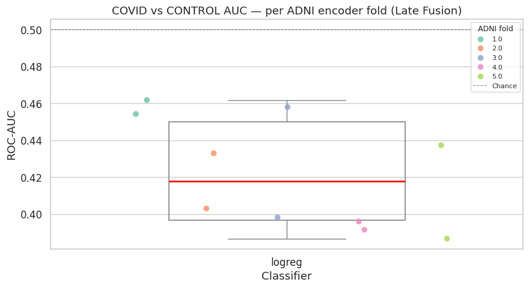

```
Per-fold latent AUC summary:
```

| model_type | mean | std | min | max | count |
| --- | --- | --- | --- | --- | --- |
| logreg | 0.422 | 0.0299 | 0.3867 | 0.4618 | 10 |

```
Raw-edges AUC summary:
```

| model_type | mean | std | min | max | count |
| --- | --- | --- | --- | --- | --- |
| logreg | 0.4666 | 0.0145 | 0.4564 | 0.4768 | 2 |

```
=== Late Fusion Ensemble (probability-level averaging) ===
```

|  | feature_set | feature_family | model_type | mean_auc | std_auc | mean_bal_acc | std_bal_acc | n_folds |
| --- | --- | --- | --- | --- | --- | --- | --- | --- |
| 0 | latent_mu_ensemble_latefusion | latent_mu | logreg | 0.4131 | 0.021 | 0.4512 | 0.0395 | 2 |

```python
# ── §8b  Per-ADNI-fold classification performance ─────────────────────
COVID_CLF_DIR = PROJECT_ROOT / "results" / "covid_vs_control_v1"
metrics_path = COVID_CLF_DIR / "Tables" / "metrics_by_model_and_feature.csv"

if metrics_path.exists():
    m = pd.read_csv(metrics_path)
    print(f"Loaded {metrics_path.relative_to(PROJECT_ROOT)}: {m.shape}")

    # Ensure columns exist (v2 adds feature_family + adni_encoder_fold)
    has_new_cols = "feature_family" in m.columns and "adni_encoder_fold" in m.columns
    if has_new_cols:
        lat = m[m["feature_family"] == "latent_mu"].copy()
    else:
        # Fallback: infer from feature_set name
        lat = m[m["feature_set"].str.startswith("latent_mu_adniFold")].copy()
        lat["adni_encoder_fold"] = lat["feature_set"].str.extract(r"(\d+)$").astype(float)

    if len(lat) > 0:
        # ── Stripplot: AUC by ADNI encoder fold, grouped by model_type ──
        fig, ax = plt.subplots(figsize=(9, 5))
        sns.stripplot(
            data=lat, x="model_type", y="auc", hue="adni_encoder_fold",
            dodge=True, jitter=0.12, s=7, alpha=0.8, ax=ax,
            palette="Set2",
        )
        # Overlay boxplot
        sns.boxplot(
            data=lat, x="model_type", y="auc",
            color="white", width=0.5, fliersize=0, ax=ax,
            boxprops=dict(facecolor="none", edgecolor="grey", lw=1.2),
            whiskerprops=dict(color="grey"), medianprops=dict(color="red", lw=2),
            capprops=dict(color="grey"),
        )
        ax.axhline(0.5, color="k", ls="--", lw=0.8, alpha=0.5, label="Chance")
        ax.set_ylabel("ROC-AUC")
        ax.set_xlabel("Classifier")
        ax.set_title("COVID vs CONTROL AUC — per ADNI encoder fold (Late Fusion)")
        ax.legend(title="ADNI fold", fontsize=8, title_fontsize=9, loc="upper right")
        fig.tight_layout()
        savefig(fig, "covid_clf_auc_per_adni_fold")
        plt.show()

        # ── Summary table ──
        print("\nPer-fold latent AUC summary:")
        lat_summary = lat.groupby("model_type")["auc"].agg(["mean", "std", "min", "max", "count"])
        display(lat_summary.round(4))

        # ── Compare with raw_edges ──
        raw = m[m["feature_set"] == "raw_edges"]
        if len(raw) > 0:
            print("\nRaw-edges AUC summary:")
            raw_summary = raw.groupby("model_type")["auc"].agg(["mean", "std", "min", "max", "count"])
            display(raw_summary.round(4))
    else:
        print("No per-ADNI-fold latent results found; run v2 of the classification script.")

    # ── Late fusion ensemble (if available) ──
    ens_path = COVID_CLF_DIR / "Tables" / "summary_latent_ensemble.csv"
    if ens_path.exists():
        ens = pd.read_csv(ens_path)
        print("\n=== Late Fusion Ensemble (probability-level averaging) ===")
        display(ens.round(4))
    else:
        print("\nLate-fusion ensemble not yet computed. Run with --latent_prediction_ensemble.")
else:
    print(f"COVID classification results not found at {COVID_CLF_DIR}")
    print("Run: conda run -n vae_ad python scripts/run_covid_vs_control_v1.py")
```

## 9 — Save Merged Table & Interpretation Notes

```python
# ── §9  Save merged table ────────────────────────────────────────────
out_csv = T / "v1_merged_covid_scores_with_metadata.csv"
df.to_csv(out_csv, index=False)
print(f"Saved merged table: {out_csv.relative_to(PROJECT_ROOT)}")
print(f"  {len(df)} rows, {len(df.columns)} columns")
print(f"  Columns: {list(df.columns)}")

# Summary of figures saved
print(f"\nFigures saved to: {FIG_DIR.relative_to(PROJECT_ROOT)}/")
for p in sorted(FIG_DIR.glob("*.png")):
    print(f"  {p.name}")

print("\n=== Interpretation hygiene ===")
print("- y_score_mean is an 'AD-likeness' score, NOT a disease-severity metric.")
print("- Recon error can reflect OOD-ness, not necessarily disease signal.")
print("- The Grupo ROC is descriptive (not cross-validated on COVID labels).")
print("- Any causal interpretation requires domain-expert review.")
```

```
Saved merged table: results/vae_3channels_beta65_pro/transfer_v1_paper_output/Tables/v1_merged_covid_scores_with_metadata.csv
  194 rows, 23 columns
  Columns: ['SubjectID', 'v1a_y_score_mean', 'v1a_y_score_std', 'v1a_y_score_min', 'v1a_y_score_max', 'v1b_y_score_mean', 'v1b_y_score_std', 'v1b_y_score_min', 'v1b_y_score_max', 'v1c_y_score_mean', 'v1c_y_score_std', 'v1c_y_score_min', 'v1c_y_score_max', 'recon_error_mean', 'recon_error_std', 'ID_n…

Figures saved to: results/vae_3channels_beta65_pro/transfer_v1_paper_output/Figures/
  adni_performance_by_fold.png
  covid_clf_auc_per_adni_fold.png
  covid_scores_by_grupo_violin.png
  covid_scores_by_sex_grupo.png
  moca_vs_scores.png
  roc_grupo_discrimination.png
  v1c_recon_error_analysis.png

=== Interpretation hygiene ===
- y_score_mean is an 'AD-likeness' score, NOT a disease-severity metric.
- Recon error can reflect OOD-ness, not necessarily disease signal.
- The Grupo ROC is descriptive (not cross-validated on COVID labels).
- Any causal interpretation requires domain-expert review.
```